# HW2

Wei_Wang_ww5

March 15, 2019

Name: Wei Wang andrew ID: ww5

## Part 1: Randomized trial for strokes (12 points)

### Preliminaries

1a.

- **Y:** What was the definition of the primary outcome in this study?
- What is (are) the variable name(s) for the outcome?

Answer: The definition of the primary outcome is death within 14 days and death or dependency at 6 months The variable names of the outcome is: **DDEAD(Dead on discharge form)** and **FDEAD(Dead at six month follow-up (Y/N))**

- **U:** what is (are) the variable name(s) for the intervention, and what is (are) their possible values?

The intervention in this study include the what descibe below: Half the patients were allocated unfractionated heparin (5000 or 12500 IU bd [twice daily]) and half were allocated avoid heparin; and, in a factorial design, half were allocated aspirin 300 mg daily and half avoid aspirin?.

Therefore the variables include: - RHEP24 Heparin within 24 hours prior to randomisation (Y/N) - RASP3 Aspirin within 3 days prior to randomisation (Y/N) - DASP14 Aspirin given for 14 days or till death or discharge (Y/N) - DASPLT Discharged on long term aspirin (Y/N) - DLH14 Low dose heparin given for 14 days or till death/discharge (Y/N) - DMH14 Medium dose heparin given for 14 days or till death/discharge (Y/N) - DHH14 Medium dose heparin given for 14 days etc in pilot (combine with above)

- **V, W:** describe the covariates included and the population being studied. Be specific where possible.

Covariates can be the the patients’ personal information including Age, sex, and the Final diagnosis of initial event DDIAGISC Ischaemic stroke; DDIAGHA Haemorrhagic stroke; DDIAGUN Indeterminate stroke; DNOSTRK Not a stroke; DNOSTRKX Comment on above.

The population of the study is: 19435 patients with suspected acute ischaemic stroke entering 467 hospitals in 36 countries were randomised within 48 hours of symptom onset.

1b. Provide descriptive statistics for in groups of {aspirin, no aspirin} use, including information on age, gender, systolic blood pressure, and conscious state. In clinical literature, this information is often referred to as “Table 1”.

```r
#set environment
loadlibs = function(libs) {
  for(lib in libs) {
    class(lib)
    if(!do.call(require,as.list(lib))) {install.packages(lib)}
    do.call(require,as.list(lib))
  }
}
libs = c("dplyr","mice","randomForest","adabag","gbm","pROC","gsubfn","chron")
loadlibs(libs)
#read dataset
stroke=read.csv("IST_corrected.csv",header = TRUE)
stroke=stroke[stroke$DASP14!="n",]
stroke=stroke[stroke$DASP14!="y",]
```

#### statistics description group by

```r
aggregate( . ~ RASP3, data=stroke[c("AGE","RCONSC","RSBP","RASP3")], FUN=range)
```

```
##   RASP3 AGE.1 AGE.2 RCONSC.1 RCONSC.2 RSBP.1 RSBP.2
## 1          23    99        1        3     90    240
## 2     N    16    98        1        3     70    290
## 3     Y    26    98        1        3     71    295
```

```r
aggregate( . ~ RASP3, data=stroke[c("AGE","RSBP","RASP3")], FUN=mean)
```

```
##   RASP3      AGE     RSBP
## 1       69.96334 159.3564
## 2     N 71.41541 160.2930
## 3     Y 73.25863 159.8614
```

```r
stroke %>%
  group_by(RASP3,SEX) %>%
  summarise(Freq = n()) %>%
  filter(RASP3!="")
```

```
## # A tibble: 4 x 3
## # Groups:   RASP3 [2]
##   RASP3 SEX    Freq
##   <fct> <fct> <int>
## 1 N     F      6879
## 2 N     M      7632
## 3 Y     F      1723
## 4 Y     M      2217
```

```r
stroke %>%
  group_by(RASP3,RCONSC) %>%
  summarise(Freq = n()) %>%
  filter(RASP3!="")
```

```
## # A tibble: 6 x 3
## # Groups:   RASP3 [2]
##   RASP3 RCONSC  Freq
##   <fct> <fct>  <int>
## 1 N     D       3232
## 2 N     F      11066
## 3 N     U        213
## 4 Y     D        824
## 5 Y     F       3080
## 6 Y     U         36
```

### Machine learning analysis

```r
# split the dataset into 50-50
smp_size <- floor(0.5 * nrow(stroke))
## set the seed to make your partition reproducible
set.seed(123)
train_stroke <- sample(seq_len(nrow(stroke)), size = smp_size)
train <- stroke[train_stroke, ]
test <- stroke[-train_stroke, ]
```

#### 1c. Let our outcome of interest be “dead or dependent at 6 months”, i.e. so that we have a binary classification problem. What percent of patients are dead or dependent at 6 months in your train set and test set?

The variable is chosen to be FDEAD

```r
length(train[train$FDEAD=="Y",])/length(train$FDEAD)
```

```
## [1] 0.01152738
```

```r
length(test[test$FDEAD=="Y",])/length(test$FDEAD)
```

```
## [1] 0.01152619
```

#### 1d. Choose which variables to include in your model.

The below variables should be removed:

DDEAD, DDEADD, DDEADC, DDEADX, DALIVE, DALIVED, DPLACE, these are all the 14 days variables.

FDEADX, comment on death is unrelated

```r
#delete columns useless
delete=c("FDEADX","DDEAD", "DDEADD", "DDEADC", "DDEADX", "DALIVE", "DALIVED", "DPLACE","COUNTRY",
         "CNTRYNUM","NCCODE","RDATE","DSIDEX","DNOSTRKX","DMAJNCHX",
         "HOURLOCAL","MINLOCAL","DAYLOCAL","FSOURCE","ID","EXPDD","EXPD14","EXPD6","SET14D",
         "ID14","OCCODE","SETASPLT","ID","DIED","DEAD1","DEAD2","DEAD3","DEAD4","DEAD5","DEAD6","DEAD7","DEAD8",
         "FDEADC","FDENNIS","FPLACE",
         "RDEF1","RDEF2","RDEF3","RDEF4","RDEF5","RDEF6","RDEF7","RDEF8")

train=train[, !(colnames(train) %in% delete), drop=FALSE]
test=test[, !(colnames(test) %in% delete), drop=FALSE]
```

#### 1e. Of the remaining variables, decide whether to exclude variables with missing data, impute them, and/or use indicator variables.

##### data clean and imputate

```r
#check number of Nans in the dataset
null=sapply(train, function(x) sum(is.na(x)))
null=null[null>0]
null
```

```
##   ONDRUG DMAJNCHD   DSIDED  DRSISCD    DRSHD  DRSUNKD     DPED   FLASTD
##        1     9636     9386     9503     9671     9598     9650     9687
##   FDEADD FU1_RECD FU2_DONE FU1_COMP       TD
##     7554        8       48      237        1
```

```r
delete2=c("DMAJNCHD", "DSIDED","DRSISCD","DRSHD","DRSUNKD","DPE","DPED","FLASTD","FDEADD","DRSUNK",
          "FAP","FAP","FRECOVER","FOAC","CMPLHEP","DRSH","DNOSTRKX","TD")
train=train[, !(colnames(train) %in% delete2), drop=FALSE]
test=test[, !(colnames(test) %in% delete2), drop=FALSE]
#train$FDEADC <- replace(train$FDEADC,is.na(train$FDEADC),0)
#test$FDEADC <- replace(test$FDEADC,is.na(test$FDEADC),0)
train$ONDRUG <- replace(train$ONDRUG,is.na(train$ONDRUG),0)
test$ONDRUG <- replace(test$ONDRUG,is.na(test$ONDRUG),0)

#imputate train data
mtrain = mice(train %>%
              select(c("FU1_RECD","FU2_DONE","FU1_COMP")) %>%
              mutate_if(is.character, as.factor),m=1,maxit = 1)
train_tmp = mice::complete(mtrain) %>% as_tibble()
# Rename columns to indicate imputation
names(train_tmp) = lapply(names(train_tmp), paste0, "_imputed")
#imputate test data
mtest = mice(test %>%
                select(c("FU1_RECD","FU2_DONE","FU1_COMP")) %>%
                mutate_if(is.character, as.factor),m=1,maxit = 1)
test_tmp = mice::complete(mtest) %>% as_tibble()
# Rename columns to indicate imputation
names(test_tmp) = lapply(names(test_tmp), paste0, "_imputed")

#reform the two dataset
delete3=c("FU1_RECD","FU2_DONE","FU1_COMP","TD","ONDRUG")
train=train[, !(colnames(train) %in% delete3), drop=FALSE]
test=test[, !(colnames(test) %in% delete3), drop=FALSE]
train=cbind(train,train_tmp)
test=cbind(test,test_tmp)

#clean dependent variable
train=train[train$FDEAD!="U",]
train=train[train$FDEAD!="",]
train$FDEAD=droplevels(train$FDEAD)

test=test[test$FDEAD!="U",]
test=test[test$FDEAD!="",]
test$FDEAD=droplevels(test$FDEAD)
```

##### logistic regression

```r
mylogit <- glm(FDEAD ~., data = train,family = "binomial")
```

##### random forest

```r
rf <- randomForest(FDEAD ~ ., data = train, ntree = 500, mtry = 6, importance = TRUE)
summary(rf)
```

```
##                 Length Class  Mode
## call                6  -none- call
## type                1  -none- character
## predicted        9640  factor numeric
## err.rate         1500  -none- numeric
## confusion           6  -none- numeric
## votes           19280  matrix numeric
## oob.times        9640  -none- numeric
## classes             2  -none- character
## importance        200  -none- numeric
## importanceSD      150  -none- numeric
## localImportance     0  -none- NULL
## proximity           0  -none- NULL
## ntree               1  -none- numeric
## mtry                1  -none- numeric
## forest             14  -none- list
## y                9640  factor numeric
## test                0  -none- NULL
## inbag               0  -none- NULL
## terms               3  terms  call
```

##### boosting

```r
boost <- boosting(FDEAD~., data=train, boos=TRUE, mfinal=3)
summary(boost)
```

```
##            Length Class   Mode
## formula        3  formula call
## trees          3  -none-  list
## weights        3  -none-  numeric
## votes      19280  -none-  numeric
## prob       19280  -none-  numeric
## class       9640  -none-  character
## importance    50  -none-  numeric
## terms          3  terms   call
## call           5  -none-  call
```

##### gradient boosting

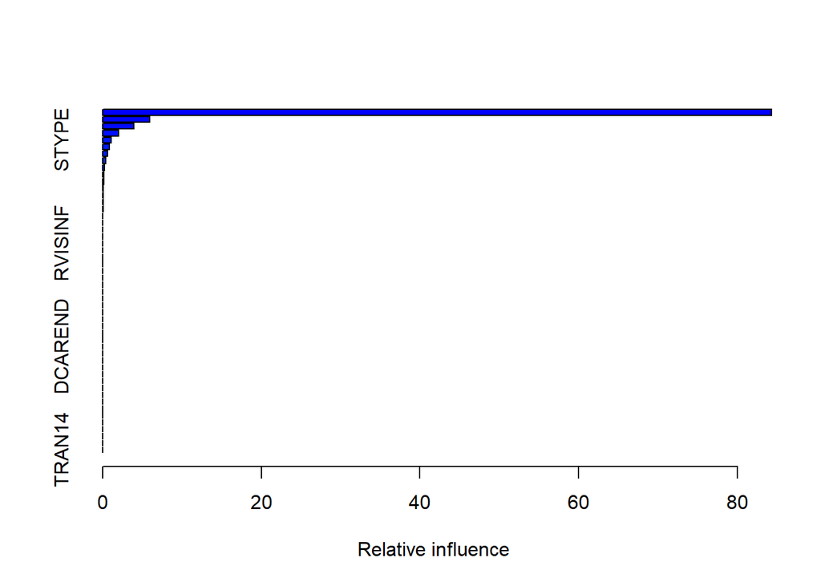

```
##                               var     rel.inf
## FU2_DONE_imputed FU2_DONE_imputed 84.31356287
## AGE                           AGE  5.96605271
## RCONSC                     RCONSC  3.95355940
## DASPLT                     DASPLT  1.99219721
## STYPE                       STYPE  1.07983852
## FU1_RECD_imputed FU1_RECD_imputed  0.81934554
## RATRIAL                   RATRIAL  0.64841877
## DSTER                       DSTER  0.39546211
## NCB14                       NCB14  0.22689773
## DOAC                         DOAC  0.18157632
## STRK14                     STRK14  0.14911278
## HOSPNUM                   HOSPNUM  0.09451329
## CMPLASP                   CMPLASP  0.07504924
## DLH14                       DLH14  0.05239971
## FU1_COMP_imputed FU1_COMP_imputed  0.05201380
## RDELAY                     RDELAY  0.00000000
## SEX                           SEX  0.00000000
## RSLEEP                     RSLEEP  0.00000000
## RCT                           RCT  0.00000000
## RVISINF                   RVISINF  0.00000000
## RHEP24                     RHEP24  0.00000000
## RASP3                       RASP3  0.00000000
## RSBP                         RSBP  0.00000000
## RXASP                       RXASP  0.00000000
## RXHEP                       RXHEP  0.00000000
## DASP14                     DASP14  0.00000000
## DMH14                       DMH14  0.00000000
## DHH14                       DHH14  0.00000000
## DSCH                         DSCH  0.00000000
## DIVH                         DIVH  0.00000000
## DAP                           DAP  0.00000000
## DGORM                       DGORM  0.00000000
## DCAA                         DCAA  0.00000000
## DHAEMD                     DHAEMD  0.00000000
## DCAREND                   DCAREND  0.00000000
## DTHROMB                   DTHROMB  0.00000000
## DMAJNCH                   DMAJNCH  0.00000000
## DSIDE                       DSIDE  0.00000000
## DDIAGISC                 DDIAGISC  0.00000000
## DDIAGHA                   DDIAGHA  0.00000000
## DDIAGUN                   DDIAGUN  0.00000000
## DNOSTRK                   DNOSTRK  0.00000000
## DRSISC                     DRSISC  0.00000000
## H14                           H14  0.00000000
## ISC14                       ISC14  0.00000000
## NK14                         NK14  0.00000000
## HTI14                       HTI14  0.00000000
## PE14                         PE14  0.00000000
## DVT14                       DVT14  0.00000000
## TRAN14                     TRAN14  0.00000000
```

```r
gbm <- gbm(FDEAD~., data=train,distribution = "gaussian")
#n.trees = 10000,shrinkage = 0.01, interaction.depth = 4
summary(gbm) #Summary gives a table of Variable Importance and a plot of Variable Importance
```

#### 1f. Construct an ROC

```r
#ROC for multiple model
rf_pred=data.frame(predict(rf, test, type="prob"))
lg_pre=predict(mylogit,newdata=test,type=c("response"))
```

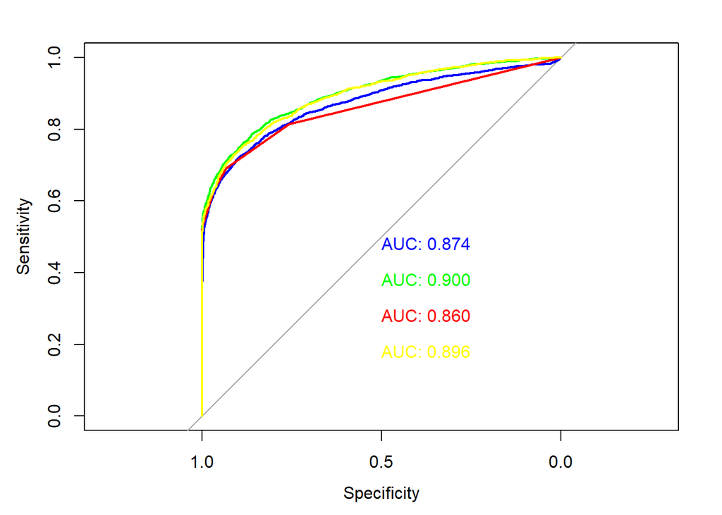

```r
boost_pred=predict(boost,test,type=c("response"))
boost_pred=data.frame(boost_pred$prob)
boost_pred=boost_pred$X2
gbm_pred=predict(gbm,test,n.trees = 100,type = c("response"))

roc_rose <- plot(roc(test$FDEAD,lg_pre), print.auc = TRUE, col = "blue")
roc_rose <- plot(roc(test$FDEAD, rf_pred$Y), print.auc = TRUE,
                 col = "green", print.auc.y = .4, add = TRUE)
roc_rose <- plot(roc(test$FDEAD,boost_pred), print.auc = TRUE,
                 col = "red", print.auc.y = .3, add = TRUE)
roc_rose <- plot(roc(test$FDEAD,gbm_pred), print.auc = TRUE,
                 col = "yellow", print.auc.y = .2, add = TRUE)
```

#### 1g. Report the variable importance

```r
# variable importance
importance(rf)
```

```
##                            N           Y MeanDecreaseAccuracy
## HOSPNUM           12.2279584   0.1850410           11.1099578
## RDELAY             7.1411730  -1.5067412            5.3082822
## RCONSC            34.0506511  22.5751904           40.0627698
## SEX                1.8679826   4.6228200            3.8407049
## AGE               30.9330645  41.1864641           47.7634565
## RSLEEP             2.4280368  -0.4270501            1.8653519
## RATRIAL           19.3733298   5.2236866           19.8703742
## RCT                2.0936229   5.3910411            4.8315323
## RVISINF            5.2113845   1.7848778            5.6058717
## RHEP24             4.2023382  -1.1145011            3.3037225
## RASP3              3.3429257   0.1177898            3.0212864
## RSBP               7.2336053   2.9784306            7.4755802
## STYPE             21.7444110   8.7096844           23.1400454
## RXASP              6.7784216  -1.1269709            5.9885583
## RXHEP              9.2388762  -2.6926328            7.9722607
## DASP14             5.6125150  -1.4783907            4.8843067
## DASPLT            23.1956924  26.1407932           32.4278481
## DLH14              8.7476914   0.2355522            8.8053785
## DMH14              5.6060832  -0.4837211            5.4167011
## DHH14              3.6575119   1.9410155            4.2115200
## DSCH               5.3619374   1.3592752            5.6592254
## DIVH               7.9306661  -1.5779393            7.0987573
## DAP                0.1589292   1.5974170            0.8902654
## DOAC              17.9892238   8.4211391           18.3978770
## DGORM              6.7530493  -0.1150492            6.1521469
## DSTER             12.5819108   7.6089452           14.3921243
## DCAA               2.2255686  -0.1368826            1.9973161
## DHAEMD             3.3007849   1.1212639            3.4355556
## DCAREND            3.8541336   0.3748510            3.8654188
## DTHROMB            1.5573549  -0.4816543            1.2710603
## DMAJNCH            5.4891457  -2.7526594            4.6850150
## DSIDE              8.2024467  -1.9052299            7.4681135
## DDIAGISC           2.1415873   1.3954996            2.6354260
## DDIAGHA            6.1330119  -2.2682072            4.9100659
## DDIAGUN           -0.3890229   1.4134316            0.5023799
## DNOSTRK            0.8164026   6.6539994            4.6501371
## DRSISC             9.1938318  -4.0552842            8.2336049
## CMPLASP            0.7907160   2.5486294            1.9704884
## H14                5.5512914  -1.3211230            4.7161937
```

[output cut: 47 more lines]

```
## DNOSTRK                  7.140119
## DRSISC                   6.315314
## CMPLASP                 12.807783
## H14                      4.524180
## ISC14                    4.924060
## NK14                     9.135068
## STRK14                  20.578361
## HTI14                    1.339043
## PE14                    11.835076
## DVT14                    1.441072
## TRAN14                   6.633501
## NCB14                   11.992205
## FU1_RECD_imputed       152.362931
## FU2_DONE_imputed      1172.662908
## FU1_COMP_imputed       158.004605
```

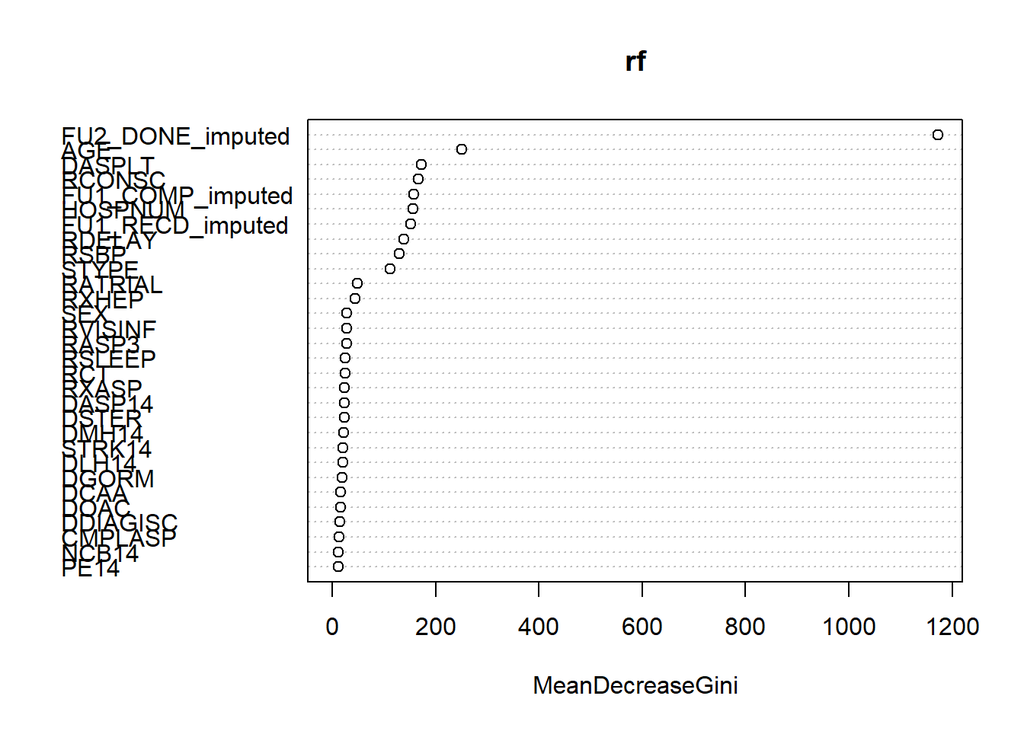

```r
library(caret)
varImpPlot(rf,type=2)
```

## Part 2. Basis functions and regularization for daily glucoses [8 points]

read dataset

```r
#read data
item=read.csv("d_labitems.csv",header = TRUE)
events=read.csv("labevents.csv",header = TRUE)
data=events[events$subject_id=="13033",]
data=data[data$itemid=="50112",]

summary(data$valuenum)
```

```
##    Min. 1st Qu.  Median    Mean 3rd Qu.    Max.
##    22.0   116.0   151.5   163.5   199.0   698.0
```

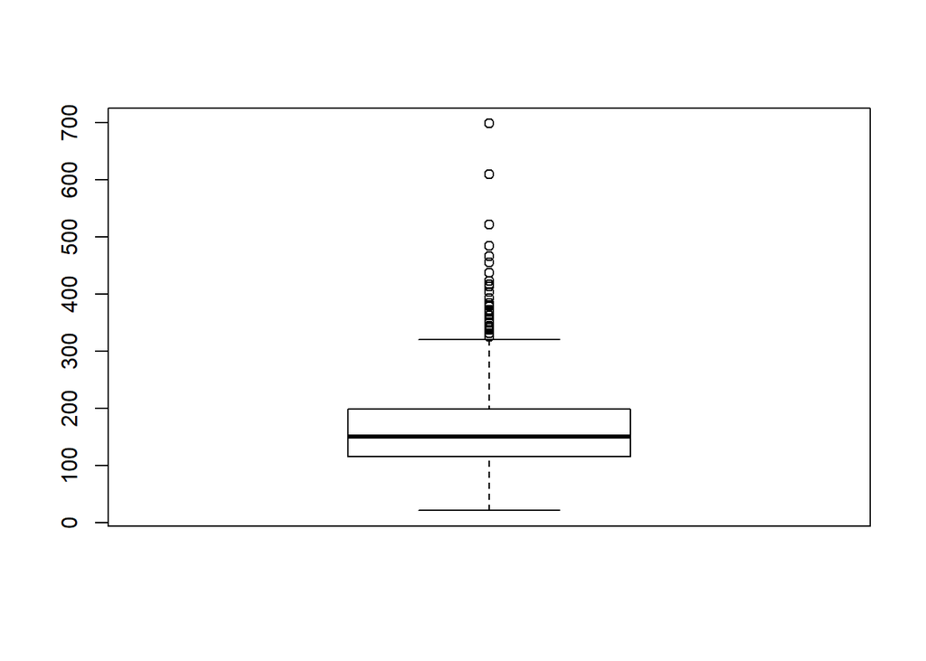

```r
boxplot(data$valuenum)
```

#### 2a. Extract the glucose data

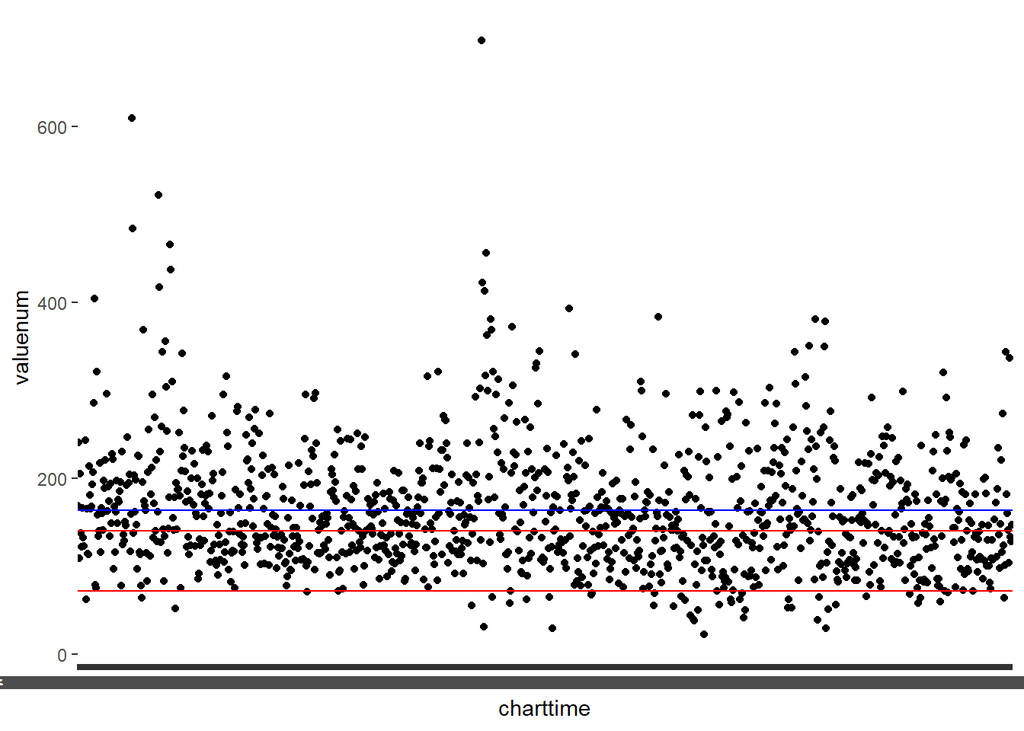

```r
library(ggplot2)
library(scales)
library(lubridate)
data$Date <- as.Date(data$charttime)
data$time <- times(strftime(data$charttime,"%H:%M:%S"))
ggplot(data, aes(charttime, valuenum)) +
  geom_point() +
  #scale_x_datetime(breaks=date_breaks("2 month"), labels="%b-%d-%Y") +
  #theme(axis.text.x=element_text(angle=90))+
  geom_hline(yintercept = mean(data$valuenum), color="blue")+
  geom_hline(yintercept = 72, color="red")+
  geom_hline(yintercept = 140, color="red")
```

#### 2b. Split the data into training set and test set

I use period = 0.5, which means 12 hours (24*0.5)

```r
#split data
bld_test=data[data$Date>"3417-5-1",]
bld_train=data[data$Date<="3417-5-1",]

#sine consine basic function
period = 0.5
K = 5

# Function for basis expansion of {sin(kx),cos(kx)} for i = 1 to K
sincos = function(dat, variable="time", period=2*pi, K=10) {
  data = dat
  for(i in 1:K) {
    data[[paste0("sin_",i)]] = sin(data[[variable]]*i*2*pi/period)
  }
  for(i in 1:K) {
    data[[paste0("cos_",i)]] = cos(data[[variable]]*i*2*pi/period)
  }
  # data$intercept = 1  # not necessary if using with models that use intercepts
  data
}
```

#### 2c. Use cv.glmnet to learn a daily trend for the individual on the training set.

Plot the coefficient profile with lambda on the x-axis. Report the lambda that performed best in CV (use lambda.min for this exercise).

```r
bld_train1 = sincos(bld_train, period=period, K=K)
bld_train1 = bld_train1 %>% dplyr::select(-charttime)%>% dplyr::select(-time)%>% dplyr::select(-Date)

# Learn a linear model, regularized
library(glmnet)  # Does regularization with (generalized) linear models
lasso = cv.glmnet(x = bld_train1 %>% select(-c(subject_id,hadm_id,icustay_id,itemid,value,valuenum,valueuom,flag))
                  %>% as.matrix(),
                  y=bld_train1$valuenum, family="gaussian")
lambda = lasso$lambda.min
lambda
```

```
## [1] 0.5505187
```

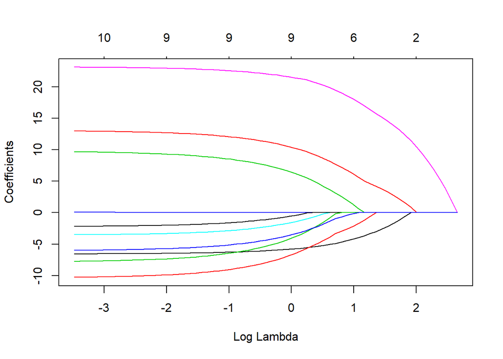

```r
plot(lasso$glmnet.fit, "lambda")
```

#### 2d. plot

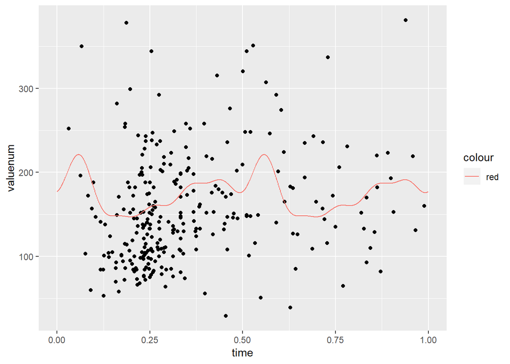

```r
#predict
bld_test1 = sincos(bld_test, period=period, K=K)
bld_test2 = bld_test1 %>% dplyr::select(-charttime)%>% dplyr::select(-time)%>% dplyr::select(-Date)

self_data=data.frame(seq(ISOdate(2000,1,31), by = "min", length.out = 1440))
self_data$time=times(strftime(self_data$seq.ISOdate.2000..1..31...by....min...length.out...1440.,"%H:%M:%S"))
self_data1=sincos(self_data, period=period, K=K)
self_data2=self_data1%>% dplyr::select(-time)%>% dplyr::select(-seq.ISOdate.2000..1..31...by....min...length.out...1440.)

self_data1[["ylasso"]] = predict(lasso,
                                 self_data2
                                #%>% select(-c(subject_id,hadm_id,icustay_id,itemid,value,valuenum,valueuom,flag))
                                %>% as.matrix(),
                              s = c(lasso$lambda.min))
# Plot
ggplot(data=bld_test1, aes(time,valuenum)) + geom_point()+
  geom_line(data = self_data1, aes(x=time,y=ylasso,color="red"))
```

#### 2e. What percent of the variation is explained by your model compared to using the training set mean?

```r
train_mean=mean(bld_train$valuenum)
#sum of square error
ssq=sum((bld_test$valuenum-train_mean)^2)
rsq=sum((bld_test1$valuenum-bld_test1$ylasso)^2)
r2=rsq/ssq
r2
```

```
## [1] 0
```

#### 2f. Make a statement about the daily variation of glucose in this individual. In particular, according to your model, when is it lowest? When is it highest?

It is high in the mid night, and in the morning about 6am, it is low. Until 12:00pm, the value is slowly increasing, and drop to lowest at 6pm.